# Geog533 Lab 10

Alexandria Quintana

## Question 1

Use R package UScensus2010county to complete the following tasks: (20 pt.)

### Question 1(a)

Plot a map of New York counties using the plot function.

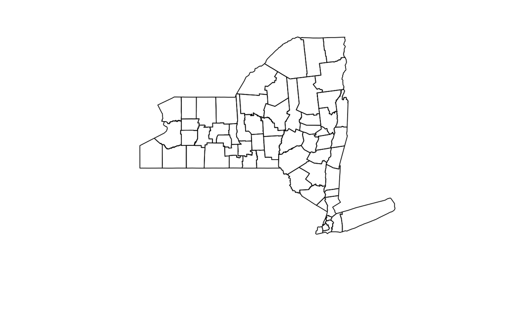

```r
if(!require(UScensus2010)) install.packages("UScensus2010")
library(UScensus2010)
if(!require(UScensus2010county)) install.county("osx")
if(!require(UScensus2010tract)) install.tract("osx")
library(UScensus2010county)
library(UScensus2010tract)
data(new_york.county10)
shp <- new_york.county10
plot(shp)
```

### Question 1(b)

Plot a map of New York counties using the qtm function.

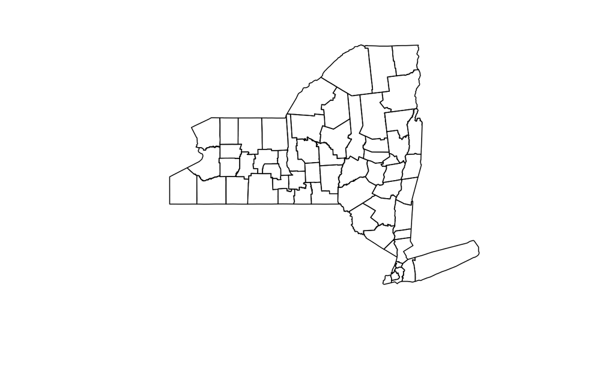

```r
library(UScensus2010county)
data(new_york.county10)
shp <- new_york.county10
df <- shp@data
plot(shp)
```

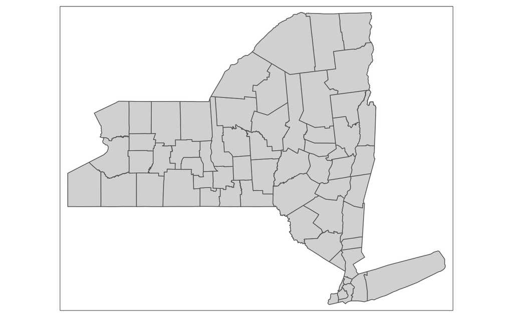

```r
if(!require(tmap)) install.packages("tmap")
library(tmap)
qtm(shp)
```

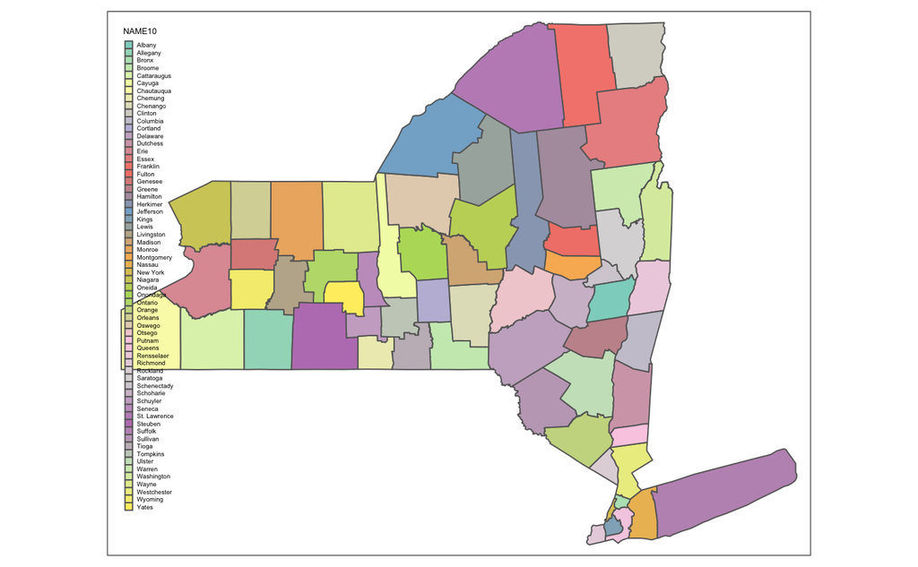

```r
qtm(shp,fill = "NAME10")
```

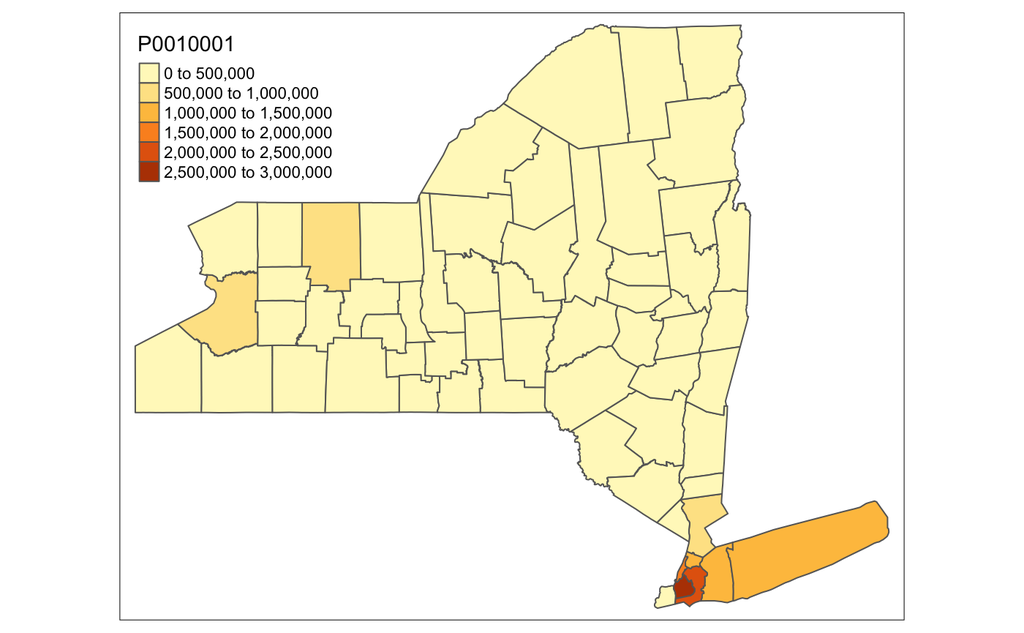

```r
qtm(shp,fill = "P0010001")
```

### Question 1(c)

How many counties in New York State?

```r
#62
nycc <- df$county
sum(nycc)
```

[output not shown]

### Question 1(d)

What’s the 3-digit fips code of Broome County?

```r
#007
```

### Question 1(e)

Compute descriptive statistics of the population column (P0010001), including total, minimum, maximum, mean, median, and skewness.

```r
pop <- df$P0010001
summary(pop)
```

[output not shown]

### Question 1(f)

Create a histogram and a boxplot of the population.

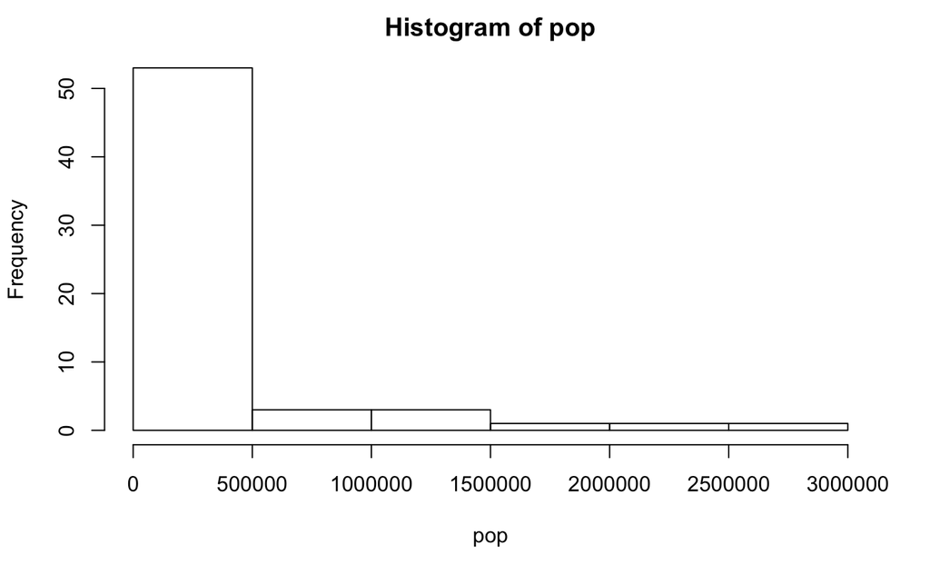

```r
hist(pop)
```

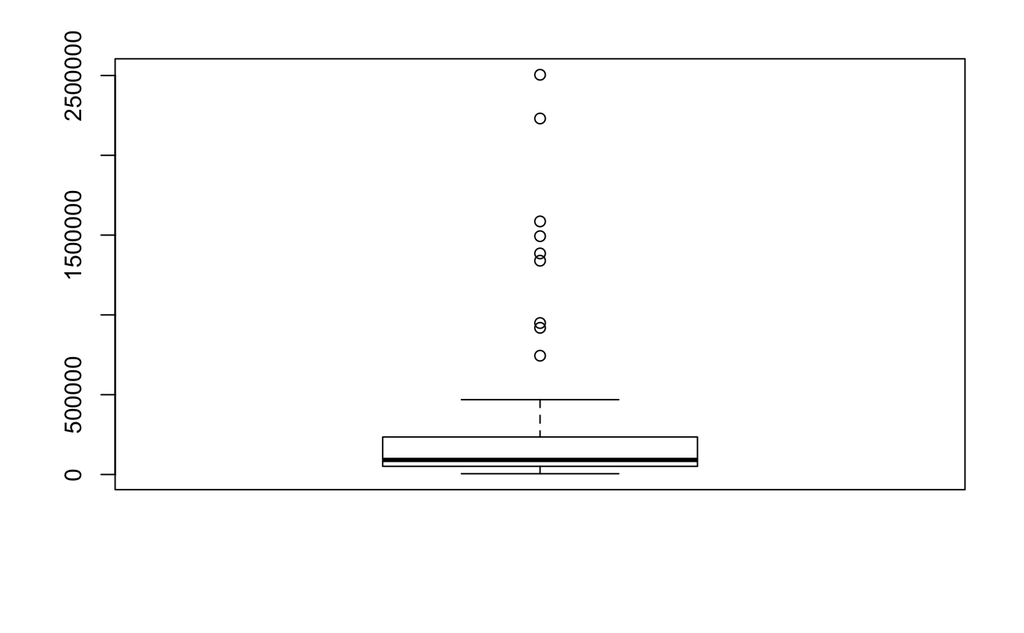

```r
boxplot(pop)
```

```r
View(df)
```

## Question 2

Use R package UScensus2010tract to complete the following tasks: (20 pt.)

### Question 2(a)

Plot a map of New York census tracts using the plot function.

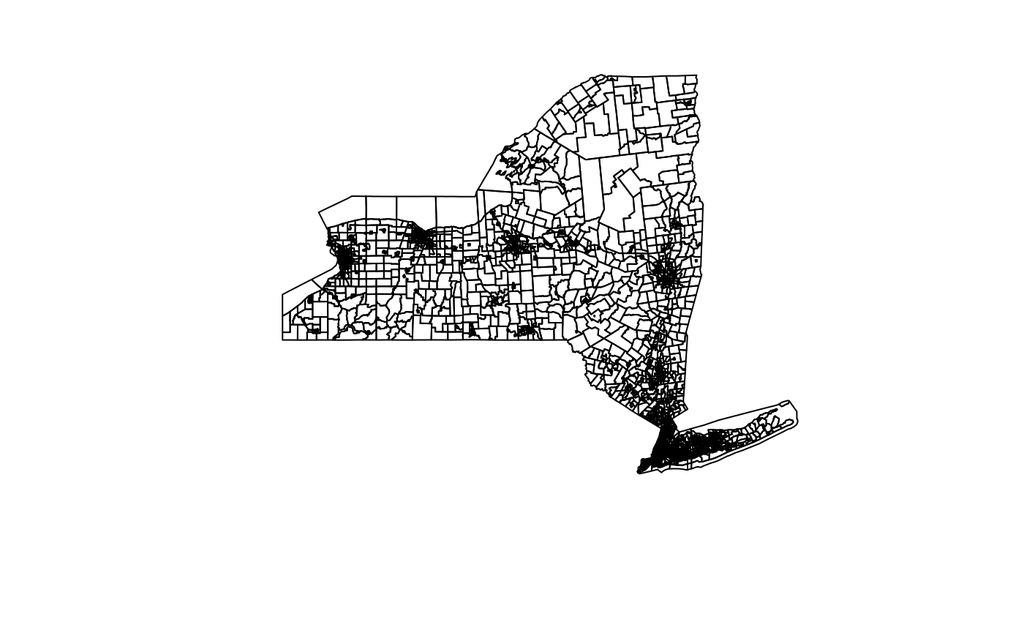

```r
if(!require(UScensus2010)) install.packages("UScensus2010")
library(UScensus2010)
if(!require(UScensus2010county)) install.county("osx")
if(!require(UScensus2010tract)) install.tract("osx")
library(UScensus2010county)
library(UScensus2010tract)
data(new_york.tract10)
shp <- new_york.tract10
plot(shp)
```

### Question 2(b)

Compute the total population based on census tracts.

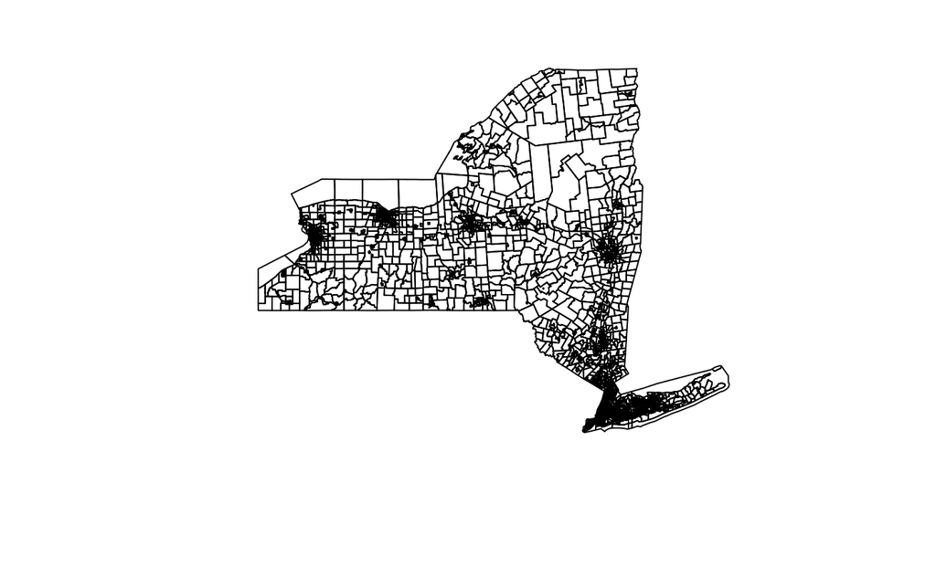

```r
library(UScensus2010county)
data(new_york.tract10)
shp <- new_york.tract10
df <- shp@data
plot(shp)
```

```r
popp <- df$P0010001
sum(popp)
```

```
[1] 19378102
```

### Question 2(c)

Select all census tracts in Broome County and plot the map.

```r
library(rgdal)
df <- shp@data
sel <- df$county == "007"
shp[sel,]
```

```
class       : SpatialPolygonsDataFrame
features    : 55
extent      : -76.13018, -75.35958, 41.99779, 42.4157  (xmin, xmax, ymin, ymax)
coord. ref. : +proj=longlat +ellps=GRS80 +datum=NAD83 +no_defs +towgs84=0,0,0
variables   : 461
names       : state, county,  tract,        fips, P0010001, P0020001, P0020002, P0020003, P0020004, P0020005, P0020006, P0030001, P0030002, P0030003, P0030004, ...
min values  :    36,    007, 000100, 36007000100,     1173,     1173,        0,        0,        0,        0,     1173,     1173,      971,        5,        0, ...
max values  :    36,    007, 014600, 36007014600,     9094,     9094,        0,        0,        0,        0,     9094,     9094,     6232,      678,       20, ...
```

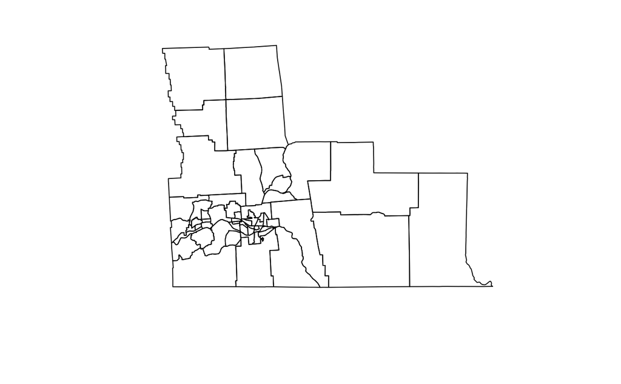

```r
plot(shp[sel,])
```

### Question 2(d)

What’s the total population of Broome County?

```r
ex <- sel
b <- ex
pop <- b$P0010001
```

[output not shown]

### Question 2(e)

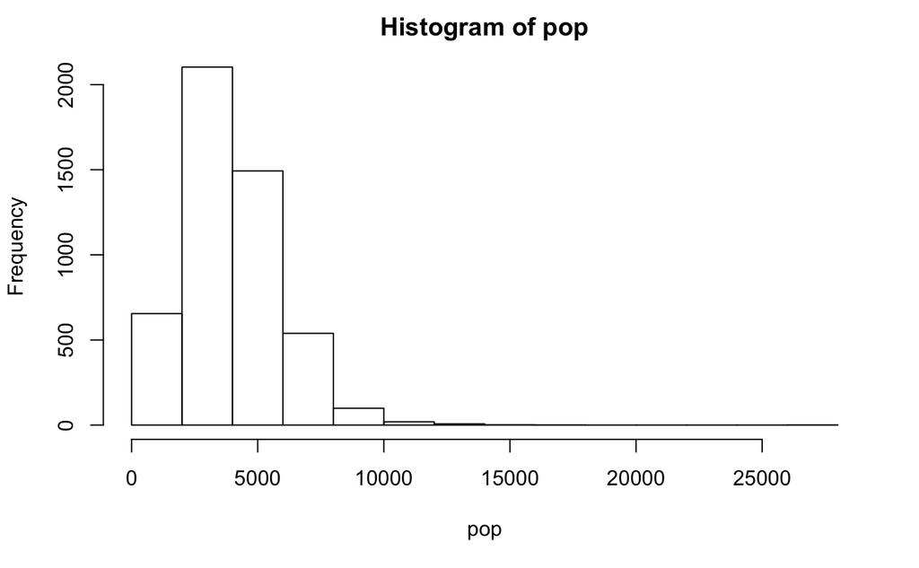

```r
library(UScensus2010county)
data(new_york.tract10)
shp <- new_york.tract10
df <- shp@data
pop <- df$P0010001
hist(pop)
```

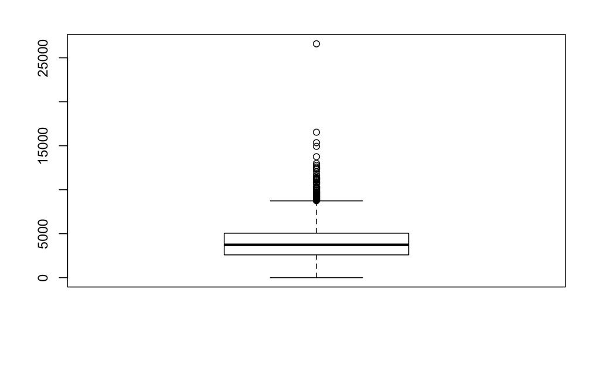

```r
boxplot(pop)
```

### Question 2(f)

Select the first five columns of the shapefile of Broome County census tract; add a new population ratio column (= census tract population / county population); save the new shapefile to the hard drive.

```r
head(shp)
```

|  | state | county | tract | fips | P0010001 | P0020001 | P0020002 | P0020003 | P0020004 | P0020005 | P0020006 | P0030001 | P0030002 | P0030003 | P0030004 | P0030005 | P0030006 | P0030007 | P0030008 | P0040001 | P0040002 | P0040003 | P0050001 | P0050002 | P0050003 | P0050004 | P0050005 | P0050006 | P0050007 | … |
| --- | --- | --- | --- | --- | --- | --- | --- | --- | --- | --- | --- | --- | --- | --- | --- | --- | --- | --- | --- | --- | --- | --- | --- | --- | --- | --- | --- | --- | --- | --- |
| new_york.tract10_0 | 36 | 099 | 951000 | 36099951000 | 2154 | 2154 | 0 | 0 | 0 | 0 | 2154 | 2154 | 2081 | 17 | 7 | 17 | 0 | 5 | 27 | 2154 | 2133 | 21 | 2154 | 2133 | 2066 | 17 | 7 | 14 | 0 | … |
| new_york.tract10_1 | 36 | 099 | 950700 | 36099950700 | 3929 | 3929 | 0 | 0 | 0 | 0 | 3929 | 3929 | 3837 | 24 | 4 | 17 | 0 | 15 | 32 | 3929 | 3867 | 62 | 3929 | 3867 | 3792 | 24 | 4 | 17 | 0 | … |
| new_york.tract10_2 | 36 | 099 | 950500 | 36099950500 | 3917 | 3917 | 0 | 0 | 0 | 0 | 3917 | 3917 | 3765 | 60 | 4 | 15 | 0 | 10 | 63 | 3917 | 3839 | 78 | 3917 | 3839 | 3707 | 53 | 4 | 15 | 0 | … |
| new_york.tract10_3 | 36 | 099 | 950100 | 36099950100 | 2452 | 2452 | 0 | 0 | 0 | 0 | 2452 | 2452 | 2393 | 5 | 6 | 6 | 0 | 14 | 28 | 2452 | 2401 | 51 | 2452 | 2401 | 2363 | 5 | 5 | 6 | 0 | … |
| new_york.tract10_4 | 36 | 099 | 950900 | 36099950900 | 3861 | 3861 | 0 | 0 | 0 | 0 | 3861 | 3861 | 3737 | 21 | 13 | 15 | 1 | 19 | 55 | 3861 | 3805 | 56 | 3861 | 3805 | 3712 | 20 | 12 | 15 | 1 | … |
| new_york.tract10_5 | 36 | 099 | 950800 | 36099950800 | 6173 | 6173 | 0 | 0 | 0 | 0 | 6173 | 6173 | 4636 | 1308 | 27 | 17 | 0 | 123 | 62 | 6173 | 5756 | 417 | 6173 | 5756 | 4416 | 1225 | 21 | 14 | 0 | … |

```r
df$newcol <- (pop/popp)
View(df)
```

## Question 3

Use R packages raster and ncdf4 to complete the following tasks: (20 pt.)

```r
if(!require(ncdf4)) install.packages("ncdf4")
library(raster)
library(ncdf4)
```

### Question 3(a)

Load the multi-band raster dataset “NDVI.nc” into R.

```r
N <- raster("/Users/Alexandria/Downloads/NDVI.nc/")
```

### Question 3(b)

Get the basic information about the dataset, including the number of rows, columns, cells, and bands; spatial resolution, extent, bounding box, and projection.

```r
N
```

```
class       : RasterLayer
band        : 1  (of  36  bands)
dimensions  : 360, 720, 259200  (nrow, ncol, ncell)
resolution  : 0.5, 0.5  (x, y)
extent      : -180, 180, -90, 90  (xmin, xmax, ymin, ymax)
coord. ref. : +proj=longlat +datum=WGS84 +ellps=WGS84 +towgs84=0,0,0
data source : /Users/Alexandria/Downloads/NDVI.nc
names       : Normalized.Difference.Vegetation.Index
z-value     : 2000-01-01
zvar        : NDVI
```

```r
nrow(N)
```

```
[1] 360
```

```r
ncol(N)
```

```
[1] 720
```

### Question 3(c)

Aggregate all bands to generate a mean NDVI raster and a maximum NDVI raster; save the two new raster datasets to the hard drive.

```r
aggregate(N)
```

```
class       : RasterLayer
dimensions  : 180, 360, 64800  (nrow, ncol, ncell)
resolution  : 1, 1  (x, y)
extent      : -180, 180, -90, 90  (xmin, xmax, ymin, ymax)
coord. ref. : +proj=longlat +datum=WGS84 +ellps=WGS84 +towgs84=0,0,0
data source : in memory
names       : Normalized.Difference.Vegetation.Index
values      : 0, 0.908925  (min, max)
```

### Question 3(d)

Plot the maps of monthly NDVI of the year 2001

```r
N2 <- brick("/Users/Alexandria/Downloads/NDVI.nc/")
N2
```

```
class       : RasterBrick
dimensions  : 360, 720, 259200, 36  (nrow, ncol, ncell, nlayers)
resolution  : 0.5, 0.5  (x, y)
extent      : -180, 180, -90, 90  (xmin, xmax, ymin, ymax)
coord. ref. : +proj=longlat +datum=WGS84 +ellps=WGS84 +towgs84=0,0,0
data source : /Users/Alexandria/Downloads/NDVI.nc
names       : X2000.01.01, X2000.02.01, X2000.03.01, X2000.04.01, X2000.05.01, X2000.06.01, X2000.07.01, X2000.08.01, X2000.09.01, X2000.10.01, X2000.11.01, X2000.12.01, X2001.01.01, X2001.02.01, X2001.03.01, ...
Date        : 2000-01-01, 2002-12-01 (min, max)
varname     : NDVI
```

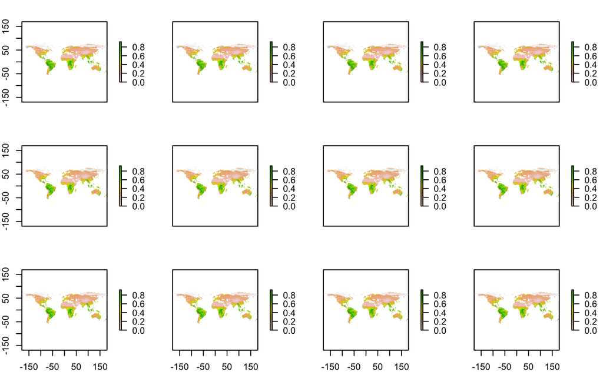

```r
ndvi2000 <- N2[[13:24]]
plot(ndvi2000, 13:24)
```

### Question 3(e)

Create histograms of monthly NDVI of the year 2001.

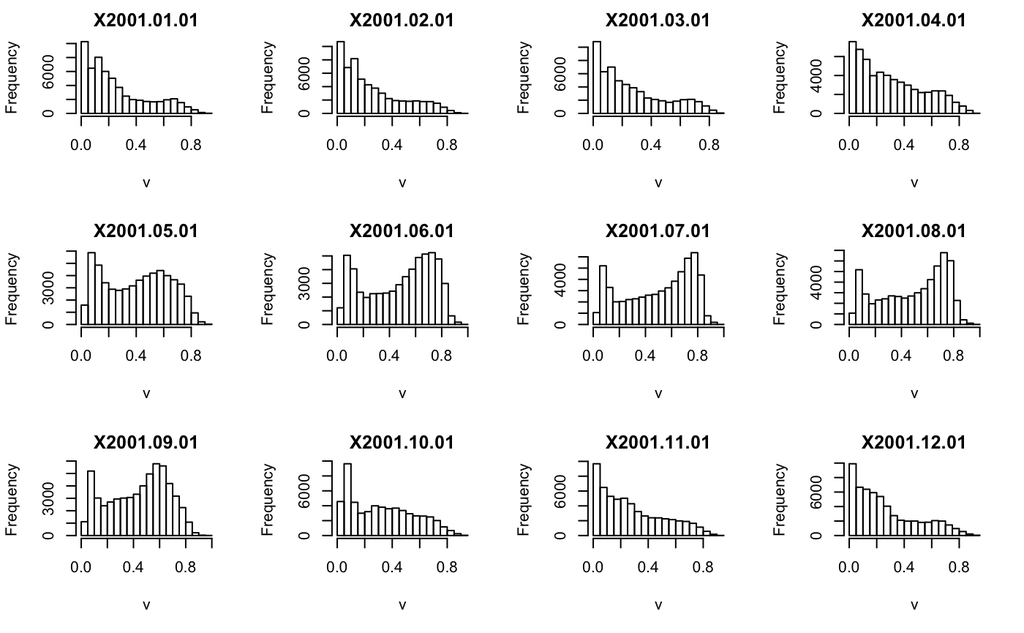

```r
hist(ndvi2000)
```

### Question 3(f)

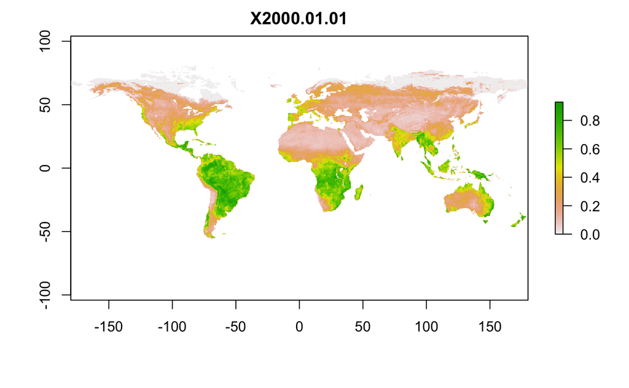

```r
plot(N2, 1)
cell <- cellFromXY(N2, cbind(15, 51))
cell.ts <- N2[cell]
cell.ts
```

```
     X2000.01.01 X2000.02.01 X2000.03.01 X2000.04.01 X2000.05.01
[1,]      0.1751      0.1866      0.2458      0.5453      0.7685
     X2000.06.01 X2000.07.01 X2000.08.01 X2000.09.01 X2000.10.01
[1,]      0.7839      0.6084      0.7097      0.6321      0.4996
     X2000.11.01 X2000.12.01 X2001.01.01 X2001.02.01 X2001.03.01
[1,]      0.3785      0.2658      0.2291      0.2481       0.253
     X2001.04.01 X2001.05.01 X2001.06.01 X2001.07.01 X2001.08.01
[1,]      0.4491      0.8188      0.7818      0.7718      0.7587
     X2001.09.01 X2001.10.01 X2001.11.01 X2001.12.01 X2002.01.01
[1,]      0.5761      0.5405      0.3898      0.2388      0.1814
     X2002.02.01 X2002.03.01 X2002.04.01 X2002.05.01 X2002.06.01
[1,]      0.2337      0.2963      0.4396      0.8059      0.8002
     X2002.07.01 X2002.08.01 X2002.09.01 X2002.10.01 X2002.11.01
[1,]   0.7618999      0.7304      0.7039      0.5167      0.3784
     X2002.12.01
[1,]      0.2899
```

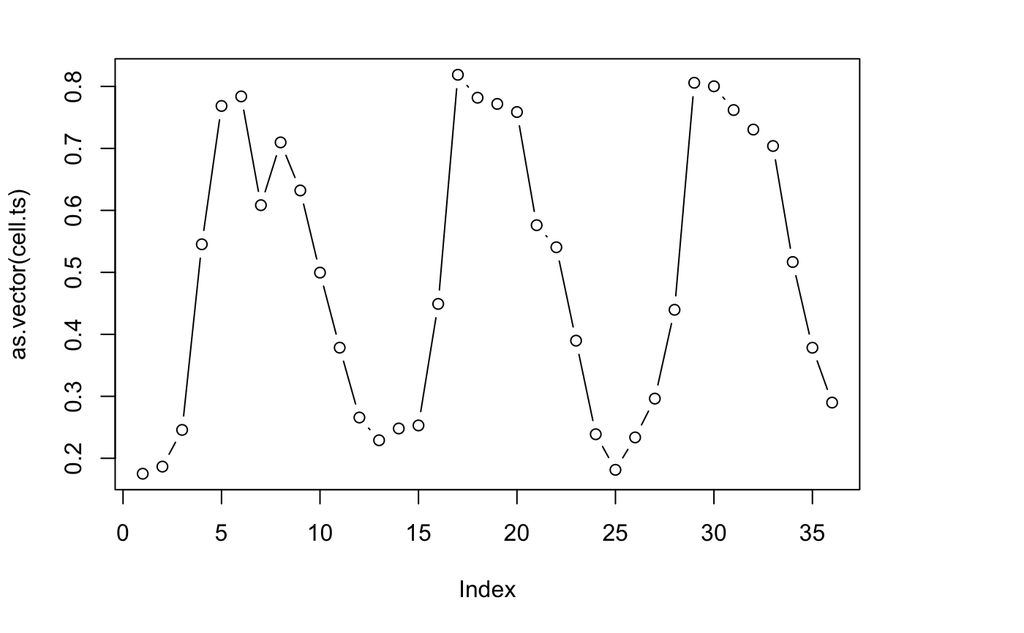

```r
plot(as.vector(cell.ts), type = "b")
```

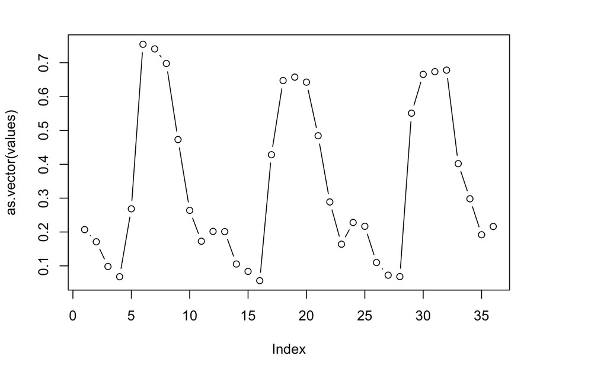

```r
values <- N2[50,50]
plot(as.vector(values), type = "b")
```